# Wrestling with Data: Is Push Sumo Streaky?

### Eugene Domrachev, Si Young Sung, I.K. Atupulazi

[figure not shown]

## Introduction

Sumo wrestling is a very simple sport. Each bout (fight) is held inside of a ring. If a fighter touches the ground inside the ring with anything but their feet, they lose. If they land outside of the ring, they also lose. Despite this simplicity, sumo has many intricacies in its execution. One such intricacy is the fighting style which a particular wrestler takes. Sumo has two main fighting styles:

| Yotsu-zumō | Oshi-zumō |
| --- | --- |
| A belt-oriented fighting style. A belt, or a *mawashi*, is the only thing a wrestler wears when competing, so it becomes a target for those looking for a grip on their opponent. Accordingly, practicio… | A beltless fighting style, focused on pushing the opponent out of the ring without using the mawashi. This includes shoves, face slaps, and a barrage of arm thrusts. |

Currently, there are several prolific thrusters in sumo's top division. Two of these wrestlers are Daieisho and Takakeisho -- who both recently won a tournament, then followed up with a middling or poor performance. Meanwhile, a yotsu practicioner, Terunofuji, has been on a ridiculously consistent tear in the past year. **This has prompted many to wonder if [pushers are actually streaky between tournaments.](https://www.reddit.com/r/Sumo/comments/l5pml0/are_pusherthrusters_streaky/)**. In this project, we will attempt to give mathematical insight into this question by looking at the tournaments in the top two (salaried) divisions of sumo.

# Outline

1. The pusher metric
   1. Creating a pusher metric
   2. Exploratory analysis
   3. Considerations
2. Wrestler scraping
   1. Our plan for data
   2. Code
   3. Considerations
3. Data Visualization
   1. Tournament visualizations
   2. Pusher metric
4. Classification & analysis with m
   1. Human cutoffs

1. Appendix
   1. Match fixing scandal

### TODO

- alternative methods (group requirement)
- line graph key
- include links to helpers
- getting rid of yokozuna (uncomment)
- clean up pie charts (spacing, title?)

*working anchors

- resources list?
- match fixing (binomial distribution)

## Glossary (read for best results!!)

- **Oshi-zumō/Oshi sumo/oshi** - style of sumo which involves a lot of pushing/thrusting techniques
- **Yotsu-zumō/Yotsu sumo/yotsu** - style of sumo focused on gripping the belt and utilizing continued contact to force displace other wrestlers
- **Mawashi** - The belt each rikishi wears
- **Rikishi** - A sumo wrestler
- **Shikona** - A wrestler's ring name. Rikishi have symbolic names that they take on for competition purposes, which usually differ from their real name
- **Basho** - The bimonthly official tournament, where wrestlers fight for 7 or 15 days depending on their divisions.
- **Kimarite** - Winning move of a bout. This can be something like frontal push out (oshidashi) or overarm throw (uwatenage). [Here is a list of all recognized kimarite.](https://en.wikipedia.org/wiki/Kimarite)
- **Juryō** - The second division from the top. Will be part of our analysis
- **Makuuchi** - The first (and top) division
- **Maegashira** - The name of the ranks inside makuuchi
- **Sanyaku** - The elite ranks of the top division. These sit above the maegashira ranks.

[figure not shown]

# Section 1: Pusher Metric

## Creating a pusher metric

To begin answering our target question, we have to talk about how to observe a pushing style from data. Our data source, [sumodb](http://sumodb.sumogames.de/Default.aspx), has a record of the winning moves (kimarite) a rikishi has used in their career. To score someone on their oshi-ness, we can compute the proportion of push-based moves to all winning moves. Say the number of all wins is $n$, and call this $p$.

That is to say, $\quad p = \frac{\text{# winning oshi moves}}{n}\quad$ so we can then define $m$, the pusher metric, as follows: $\quad m = (0.5 - p) \cdot log(n)$

It can be easily seen that those who tend towards push sumo will receive a negative score, while those who tend away from it will have a positive score.

Some rationale for the formula:

1. If a wrestler is dead even between oshi and another other style, we want their score to be zero. This is the reason for the $0.5$ term.
2. We want to give confidence to wrestlers with high win volume in whichever direction they lean, but in a limited fashion. Hence, the $log(n)$ term.

**Why not make this a binary metric?**

Wrestlers sometimes transition in their fighting style. Wrestlers like Akebono, Musashimaru, and Asashoryu used to be oshi specialists, but picked up the yotsu style as they rose through the ranks and sustained injuries. For these wrestlers, it would be innacurate to classify them as one or the other (although we will be looking into this later), so giving a confidence-based estimate is a good option here.

To make sure this is an apt measure of oshi, let's do a sanity check by testing it on some known wrestlers. The oshi moves of a wrestler will be plotted in red, and others will be in blue.

## Pusher metric exploratory analysis

```python
# plotting and data processing
import matplotlib as mpltlib
import matplotlib.pyplot as plt
import matplotlib.patches as  mpatches
import seaborn
import numpy as np
import pandas as pd

# auxiliary
import requests, re, json
from bs4 import BeautifulSoup
import datetime
import math

# custom helpers
import rank_helper
import kimarite_helper

# ML tooling
from sklearn.cluster import KMeans
from sklearn.linear_model import LogisticRegression
import statsmodels.formula.api as smf
```

```python
# graph package settings
plt.style.use('ggplot')
plt.rcParams["figure.figsize"] = (15, 10)
```

```python
"""
Take in a list of wrestlers by their shikona, and output a list of lists containing the wrestler's
significant winning moves.
"""
def kimarite_list_by_name(rikishi_list):

    base_URL = "http://sumodb.sumogames.de/"
    shikona_search_URL = "http://sumodb.sumogames.de/Rikishi.aspx?shikona="

    # this will look like  [ ("Takakeisho", [url_to_kimarite]),  ... ]
    kimarite_URL_collection = []

    for rikishi in rikishi_list:


        # get the wrestler's page by searching their name
        basepage = requests.get(shikona_search_URL + rikishi)
        soup = BeautifulSoup(basepage.content, 'html.parser')

        # if shikona is unique, there will by a 'bouts by kimarite' link
        kimarite_page = soup.find('a', href = re.compile(r'Rikishi_kim*'))

        # if it's not unique, you will come to a page with a table of wrestlers
        # with this shikona by date. get the latest one by date
        # example: http://sumodb.sumogames.de/Rikishi.aspx?shikona=Terao
        if not kimarite_page:
            #print(f"non-unique shikona found ({rikishi})...")
            kimarite_page = soup.find('tbody').findAll('a', href = re.compile(r'Rikishi.aspx'))
            basepage = requests.get("http://sumodb.sumogames.de/" + kimarite_page[-1]['href'])
            soup = BeautifulSoup(basepage.content, 'html.parser')
            kimarite_page = soup.find('a', href = re.compile(r'Rikishi_kim*'))

        #print(kimarite_page['href'])
        kimarite_URL_collection.append( (rikishi, base_URL + kimarite_page['href']) )



    # pie chart requires size and label lists. so, we will make a list like
    # [ ( "Name", [kimarite_name, ...], [kimarite_amt, ...] ),   ... ]
    kimarite = []

    for (shikona, kimarite_URL) in kimarite_URL_collection:
        print(f"processing {shikona}...")
        basepage = requests.get(kimarite_URL)
        soup = BeautifulSoup(basepage.content, 'html.parser')

        # get winning data table
        kimarite_wins = soup.find('table', class_="ro_left")

        # this gets all winning moves in like
        # [<tr><td class="rb_kim">oshidashi</td><td class="right"><a href="#0oshidashi">143</a></td></tr>, ...]
        cells = kimarite_wins.find_all('tr')

        kimarite_labels, kimarite_amts = [], []

        for cell in cells:
            win_name_tag, win_amt_tag = cell.find_all('td')
            kimarite_labels.append(win_name_tag.text.strip())
            kimarite_amts.append(int(win_amt_tag.text.strip()))


        # at this point we have all kimarite. reduce it so that only moves with >= 5% significance are displayed
        up_to_index = 0
        total_wins = sum(kimarite_amts)
        for i in range(0, len(kimarite_amts)):
            amt = kimarite_amts[i]
            # we find the most significant kimarite under 10%
            if amt / total_wins < 0.05:
                up_to_index = i
                break

        # we now slice off everything up to and past this point, label it as 'other'
        kimarite_labels = kimarite_labels[:up_to_index] + ["other"]
        kimarite_amts = kimarite_amts[:up_to_index] + [sum(kimarite_amts[up_to_index:])]

        kimarite.append((shikona, kimarite_labels, kimarite_amts))

    print("done extracting kimarite!")
    return kimarite
```

```python
"""
Using the data from kimarite_list_by_name(), visualize the kimarite of the passed
rikishi list.
"""
def make_graphs(fighters):

    plt.subplots_adjust(hspace=0.5, wspace=0.3)
    plt.rcParams["figure.figsize"] = (20, math.ceil(len(fighters)/4)*5)


    fig, axs = plt.subplots(math.ceil(len(fighters)/4), 4)
    axs = axs.flatten()
    ai = 0

    # this is auxiliary for exploration into kimarite category.
    # we only care about oshi/non oshi, so we don't use this... but you might :)
    color_group_general = {
                'Kihonwaza: Basic technique': 'red',
                'Nagete: Throwing technique': 'blue',
                'Kakete: Leg tripping technique': 'green',
                'Hinerite: Twist down technique': 'black',
                'Sorite: Backwards body drop': 'brown',
                'Tokushuwaza: Special technique': 'yellow',
                'Higi: Non-technique': 'gray',
                'Others': 'gray',
                None: 'gray'
    }


    for (rikishi, kimarite_labels, kimarite_amts) in kimarite_list_by_name(fighters):

        ax1 = axs[ai]

        n = sum(kimarite_amts)
        w = 0
        for i in range(0, len(kimarite_amts)):
            w += kimarite_amts[i] if kimarite_helper.is_oshi(kimarite_labels[i]) else 0
        p = w / n

        # explode top three kimarite
        explode = tuple( [0.05]*3 + ([0] * (len(kimarite_labels)-3)) )

        #colors = [color_group_general[kimarite_helper.classify(x)] for x in kimarite_labels]
        # highlighting OSHI in RED
        colors = ['red' if kimarite_helper.is_oshi(x) else 'blue' for x in kimarite_labels]

        ax1.pie(kimarite_amts, explode=explode, labels=kimarite_labels, autopct='%1.1f%%',
                shadow=True, startangle=90, #textprops={'color':"b"},
                #colors=map(lambda x: color_d[kimarite_helper.classify(x)], kimarite_labels)
                colors=colors
                )
        ax1.title.set_color('black')
        ax1.axis('equal')
        ax1.set_title( rikishi + " (n=%s, p=%s, m=%s" % (n, "{:.2f}".format(p), "{:.2f}".format((0.5 - p)  * math.log10(n))) + ")")

        ai += 1

    while ai < 4 * math.ceil(len(fighters)/4):
        axs[ai].axis('off')
        ai += 1

    plt.show()
```

```python
# define some pushers and non-pushers to show the metric for

pushers = [
    "Takakeisho", "Daieisho", "Chiyotaikai", "Abi",
    "Onosho", "Takanosho", "Hokutofuji", "Tamawashi",
    "Chiyotairyu", "Chiyomaru",
]

not_pushers = [
    "Terunofuji", "Hakuho", "Hoshoryu", "Terutsuyoshi",
    "Harumafuji", "Ichinojo","Enho", "Tochinoshin",
    "Takarafuji", "Asashoryu",
    # these two transitioned to yotsu later in their career.
    "Musashimaru",
	"Akebono",
]
```

```
processing Takakeisho...
processing Daieisho...
processing Chiyotaikai...
processing Abi...
processing Onosho...
processing Takanosho...
processing Hokutofuji...
processing Tamawashi...
processing Chiyotairyu...
processing Chiyomaru...
done extracting kimarite!
```

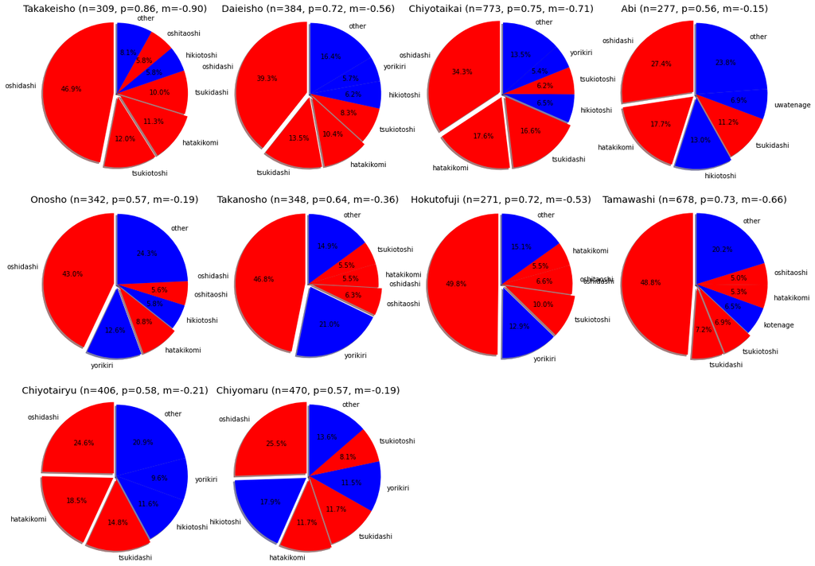

```python
make_graphs(pushers)
```

Notice how the thrusters with larger red area tend to have a higher p, and ultimately a lower m. Wrestlers like Takakeisho and Daieisho are clearly thrusters, which shows with their m score. Abi tends to the oshi style but not heavily, giving him an m score closer to zero than the rest. Seems like it works with pushers.

```
processing Terunofuji...
processing Hakuho...
processing Hoshoryu...
processing Terutsuyoshi...
processing Harumafuji...
processing Ichinojo...
processing Enho...
processing Tochinoshin...
processing Takarafuji...
processing Asashoryu...
processing Musashimaru...
processing Akebono...
done extracting kimarite!
```

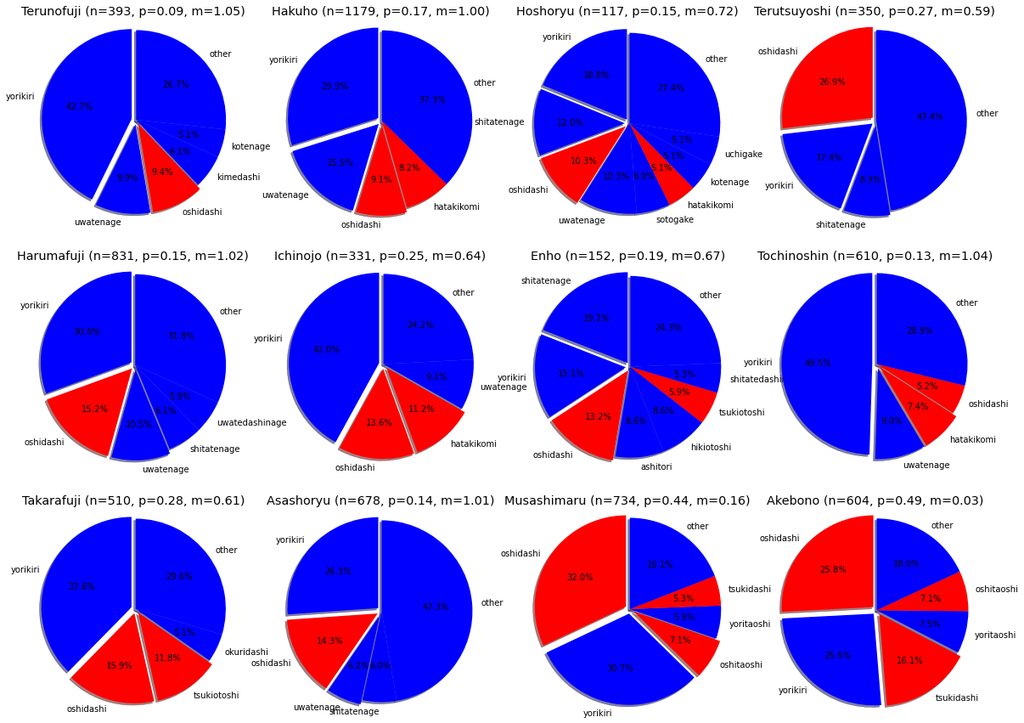

```python
make_graphs(not_pushers)
```

The m score in this batch are positive, capping out at around 1. Again, wrestlers like Terunofuji are scored succesfully as "certain" non-oshi wrestlers. Meanwhile, Akebono has a very slight positive score. It seems to work on this end of the spectrum, as well. We will keep the definition of m moving forward.

## Considerations on the m metric

1. **The unrestricted $log(n)$ term should be monitored.** In practice, Hakuho, the most winning wrestler in sumo history, has won about 1200 bouts, and has an $m$ of 1.00. Furthermore, the m distribution will be within an appropriate range, which will be shown post data scraping.
2. **The metric shows an oshi tendency or lack thereof, but NOT necessarily a yotsu tendency.** Non-oshi kimarite are not exclusively yotsu, there are are some specialized throw techniques and non-techniques that are not commonly used in yotsu. For this reason, m should be thought of a measure of "oshi and non-oshi."
3. **Some fighters, Like Akebono and Musashimaru, transitionitioned from an oshi to a yotsu style throughout their career. Shouldn't we keep track of m up to any date as you're scraping wrestler information?** Yes, we should. However, this would extend the runtime of scraping by a significant amount. The plan to scrape wrestler information is as follows:
   - Access their page by an increasing rikisihi ID (as defined by sumodb).
   - Read their basic tournament history on this page (has W/L, but NOT kimarite).
   - Once this is all done, create a different dataframe with the metrics calculated by accessing the kimarite page of relevant scraped wrestlers.

The first two steps alone takes around 13,000 requests, which is a significant amount of time to process. Adding another request to each basho's page for that wrestler (which DOES have kimarite) would increase that number many times. For the scope of this project, we will not consider the changing $m$ score, but compute it only for a wrestler's career.

[figure not shown]

# Part 2: Scraping for all wrestler data

## Our plan for data

Before we get going, we should clearly define what we want, how we're going to get it, and how we'll deal with missing data.

#### What

In our analysis for "streakiness," we are going to be looking at performances at consecutive tournaments. So, we need a dataframe with all the tournament histories that we care about. That being said, **we only care about the histories of wrestlers which have reached the top two divisions** (this is defined in the scope of our question). We will ignore those who have their career high rank below those two divisions.

#### How

To get this data, we visit a wrestler's page by an integer ID. Once there, their highest rank, as well as tournament history, is displayed in a table. First, check that a wrestler has reached the top two divisions. If not, skip them. Otherwise, process their tournament table. An example of a wrestler page can be seen [here.](http://sumodb.sumogames.de/Rikishi.aspx?r=1123)

#### Missing data

Some rikishi have missing win/loss order records for their tournament data. In this case, the kimarite used in the tournament is not recorded. Take [this page](http://sumodb.sumogames.de/Rikishi.aspx?r=11111) as an example. If we see any missing rows, we drop the wrestler from processing as we do not have a way to accurately calculate their $m$ score. Imputing a mean or empty value would take away from the analysis on the $m$ distribution.

*Let's get started!*

## Scraping all tournament data

```python
"""
Get the dataframe with all of a wrestler's tournaments.
Each row will be one of their tournament performances.
This dataframe will include:
    -
"""

def get_df_by_id(id):

    # example page: http://sumodb.sumogames.de/Rikishi.aspx?r=1123

    URL = f"http://sumodb.sumogames.de/Rikishi.aspx?r={id}"
    basepage = requests.get(URL)
    soup = BeautifulSoup(basepage.content, 'html.parser')

    # find the wrestler's top career rank
    try:
        highest = soup.find('table', class_='rikishidata')
        highest = highest.find('table', class_='rikishidata')
        highest = highest.find('tr').findAll('td')[1].contents[0]
        highest = str(highest.split()[0]).replace('-', '')
    except:
        print(f"{id} skipped prelim")
        return

    # we're only considering those who made it to the top division
    if not rank_helper.rank_is_top(highest, True):
        print(f"{id} rejected")
        return


    get_data = soup.find_all('tr')


    # texts that we have to convert, since it's an image in the table
    txt1 = '<img border="0" src="img/hoshi_shiro.gif"/>'     # win, white circle
    txt2 = '<img border="0" src="img/hoshi_yasumi.gif"/>'    # withdrawal, dash
    txt3 = '<img border="0" src="img/hoshi_kuro.gif"/>'      # loss, black circle
    txt4 = '<img border="0" src="img/hoshi_fusenpai.gif"/>'  # ff, black square
    txt5 = '<img border="0" src="img/hoshi_fusensho.gif"/>'  # hoshi_fusensho, opp withdrawal, white square


    # convert the images to W(win) F(forfeit) L(loss)
    edited = str(get_data).replace(txt1, 'W')
    edited = edited.replace(txt2, 'F')
    edited = edited.replace(txt3, 'L')
    edited = edited.replace(txt4, 'A') # absence means a loss, but we count it as something separate
    edited = edited.replace(txt5, 'W') # enemy ff counts as win


    # put the record table into a dataframe
    test = pd.read_html(edited)
    df = test[2]

    # rename columns
    df.columns = ['Date','Rank', 'Series','W_L','Yusho_standing', 'Height/weight']

    # if there is no series, there is no relevant data here most likely (record too old, mae-zumo)
    # example: http://sumodb.sumogames.de/Rikishi.aspx?r=11111
    # this rikishi has no kimarite data anyhow, so we don't need them in the final dataframe.
    df.dropna(subset = ["Series"], inplace=True)

    # drop any possible name-change banner columns
    df = df[df.W_L.apply(lambda x: '-' in x)]

    # convert dates to datetime
    df['Date'] = pd.to_datetime(df['Date'].astype(str), format='%Y.%m')

    # we don't really care about yusho standing and height/weight. drop them
    df = df.drop(columns=['Yusho_standing', 'Height/weight'])


    # calculate streaks
    forfeit_list = []
    win_list = []
    lose_list = []
    ab_list = []
    streak_list = []

    for index, row in df.iterrows():
        f_count = 0
        w_count = 0
        l_count = 0
        a_count = 0
        row_series = row['Series']


        # get W/L/F/A by counting
        for s in row_series:
            if(s == 'F'):
                f_count += 1
            if(s == 'W'):
                w_count += 1
            if(s == 'L'):
                l_count += 1
            if(s == 'A'):
                a_count += 1

        forfeit_list.append(f_count)
        win_list.append(w_count)
        lose_list.append(l_count)
        ab_list.append(a_count)

        # basho is a streak when you win 4 or more bouts in a row
        streak_list.append(sum(1 for x in re.finditer(r'W{4,}', row['Series'])))


    # make new columns
    df['Win'] = win_list
    df['Loss'] = lose_list
    df['Forfeit'] = forfeit_list
    df['Absence'] = ab_list



    # calculate win rate: (W/# bouts fought), ignoring the games forfeited
    df['Winrate'] = (df['Win']/(15 - (df['Forfeit'] + df['Absence'])))*100
    # remove nans
    df['Winrate'] = df['Winrate'].replace(np.nan,0)
    # round the numbers to the 2 decimal place
    df['Winrate'] = df['Winrate'].round(2)


    # change streak column to Y or N
    change = []
    for s in streak_list:
        if(s > 0):
            change.append('Y')
        else:
            change.append('N')


    df['Streak(Wins)'] = change
    # apply the sumodb id to all columns
    df.insert(0, 'id', id)


    return df
```

```python
"""
Combine all scraped dataframes of a btach into one, and write it to a batch file.
"""

# The current highest id is 12670.
# 2933 is an empty test case.

# check problematic pages aren't just connection issues
e = []

# each batch represents a 1000 wrestlers. Note that some are dense, some are sparse
for batch in range(0, 13):

    aggregate_df = pd.DataFrame()

    for i in range(1 + 1000 * batch, 1000 * (batch+1)):
        print(f"Processing {i}...")
        next = None
        try:
            next = get_df_by_id(i)
        except:
            e.append(i)
        aggregate_df = aggregate_df.append(next, ignore_index=True)

    aggregate_df.to_csv(f'tournaments_all_{batch}.csv', index = False)
```

```python
# example dataframe for the 13th batch
aggregate_df
```

|  | id | Date | Rank | Series | W_L | Win | Loss | Forfeit | Absence | Winrate | Streak(Wins) |
| --- | --- | --- | --- | --- | --- | --- | --- | --- | --- | --- | --- |
| 0 | 12015 | 2012-05-01 | Jk8e | FWLFFLLFWFWFWFF | 4-3 | 4 | 3 | 8 | 0 | 57.14 | N |
| 1 | 12015 | 2012-07-01 | Jd76e | WFFWFWWFFLWFFWF | 6-1 | 6 | 1 | 8 | 0 | 85.71 | N |
| 2 | 12015 | 2012-09-01 | Jd5w | FLFWFWFWLFWFFLF | 4-3 | 4 | 3 | 8 | 0 | 57.14 | N |
| 3 | 12015 | 2012-11-01 | Sd86w | FFFFFFFFFFFFFFF | 0-0-7 | 0 | 0 | 15 | 0 | 0.00 | N |
| 4 | 12015 | 2013-01-01 | Jd47e | LFWFFWWFLFFWFWF | 5-2 | 5 | 2 | 8 | 0 | 71.43 | N |
| ... | ... | ... | ... | ... | ... | ... | ... | ... | ... | ... | ... |
| 1586 | 12575 | 2020-07-01 | Ms10w | WFLFFWFWWFWFFFW | 6-1 | 6 | 1 | 8 | 0 | 85.71 | N |
| 1587 | 12575 | 2020-09-01 | Ms2w | FFFFFFFFFFFFFFF | 0-0-7 | 0 | 0 | 15 | 0 | 0.00 | N |
| 1588 | 12575 | 2020-11-01 | Ms2w | FLWFWFWFLFLFWFF | 4-3 | 4 | 3 | 8 | 0 | 57.14 | N |
| 1589 | 12575 | 2021-01-01 | J14w | LWWLLWWLLWWLWWL | 8-7 | 8 | 7 | 0 | 0 | 53.33 | N |
| 1590 | 12575 | 2021-03-01 | J11e | LWLLLLLLLWWWWWW | 7-8 | 7 | 8 | 0 | 0 | 46.67 | Y |

1591 rows × 11 columns

```python
"""
Merge all the dataframes by file, and write it to a final output file.
"""

aggregate_df = pd.DataFrame()

for i in range(0, 13):
    if i != 10: # there is nothing in this file.
        df = pd.read_csv(f'tournaments_all_{i}.csv')
        aggregate_df = aggregate_df.append(df)

#aggregate_df = aggregate_df.groupby('id').filter(lambda x : len(x) > 5)
aggregate_df.to_csv(f'tournaments_all.csv', index = False)

aggregate_df.shape
```

```
(67350, 11)
```

We have now compiled the recorded tournaments of all "relevant" wrestlers. We continue to find the statistics ($m, n, p$ as defined in the first section) of each wrestler into a new dataframe.

```python
# load the combined tournament dataframe
df = pd.read_csv(f'tournaments_all_final.csv')
print(df.shape)

# example of selecting only basho fought in the top two divisions
df = df[df.Rank.apply(lambda x: rank_helper.rank_is_top(x))]
print(df.shape)
```

```
(67351, 11)
(34995, 11)
```

```python
"""
Get the push score (m), push win% (p), and number of wins (n) of a given wrestler by their ID.
"""
def get_m_by_id(id):

    kimarite_URL = f"http://sumodb.sumogames.de/Rikishi_kim.aspx?r={id}"
    print(f"processing {id}...")
    basepage = requests.get(kimarite_URL)
    soup = BeautifulSoup(basepage.content, 'html.parser')

    # get winning data table
    kimarite_wins = soup.find('table', class_="ro_left")

    # this gets all winning moves in like
    #[<tr><td class="rb_kim">oshidashi</td><td class="right"><a href="#0oshidashi">143</a></td></tr>, ...]
    cells = kimarite_wins.find_all('tr')

    kimarite_labels, kimarite_amts = [], []

    for cell in cells:
        win_name_tag, win_amt_tag = cell.find_all('td')
        kimarite_labels.append(win_name_tag.text.strip())
        kimarite_amts.append(int(win_amt_tag.text.strip()))


    # at this point we have all kimarite. reduce it so that only moves with >= 5% significance are displayed
    up_to_index = 0
    total_wins = sum(kimarite_amts)
    for i in range(0, len(kimarite_amts)):
        amt = kimarite_amts[i]
        # we find the most significant kimarite under 5%
        if amt / total_wins < 0.05:
            up_to_index = i
            break

    # we now slice off everything up to and past this point, label it as 'other'
    kimarite_labels = kimarite_labels[:up_to_index] + ["other"]
    kimarite_amts = kimarite_amts[:up_to_index] + [sum(kimarite_amts[up_to_index:])]

    #print((shikona, kimarite_amts, kimarite_labels))

    n = sum(kimarite_amts)
    if n == 0:
        return (None, None, None)

    w = 0
    for i in range(0, len(kimarite_amts)):
        w += kimarite_amts[i] if kimarite_helper.is_oshi(kimarite_labels[i]) else 0

    p = w / n
    m = (0.5 - p)  * math.log10(n)
    return (m, p, n)
```

```python
stats_df = pd.DataFrame(columns = ["id", "m", "p", "n"])
d = []

# calculate the statistics for each unique wrestler in the combined dataframe.
for i in df.id.unique():

    m, p, n = get_m_by_id(i)
    if m:
        stats_df = stats_df.append({'id': i, 'm': m, 'p': p, 'n': n}, ignore_index=True)
    else:
        d.append(i)

# write the whole thing
stats_df.to_csv(f'stats_by_id.csv', index = False)

# we have the tournament history of 1080 unique wrestlers to analyze!
print(stats_df.shape)
```

```
(1080, 4)
```

```python
stats_df.head(3)
```

[output not shown]

[figure not shown]

# Section 3: Visualization of tournament data

## Tournament visualizations

We have our data, let's take a look at it!

```python
# load our tournament dataframe from the created file
df = pd.read_csv(f'tournaments_all_final.csv')

# remove absent tournaments -- those with 15 withdrawals
df = df[df.Forfeit != 15.0]

# top 2 divisions
upper = df[df.Rank.apply(lambda x: rank_helper.rank_is_top(x))]

# top division
div1 = upper[upper.Rank.apply(lambda x: rank_helper.divisions[rank_helper.long_rank(x)] >= 6)]

# sanyaku
s = div1[div1.Rank.apply(lambda x: rank_helper.rank_is_sanyaku(x))]
```

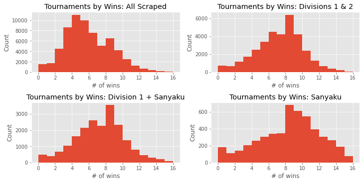

```python
# note that this includes a mix of data -- lower division records will be 7 matches total,
# while top divisions will be 15.

frames = [(df, "All Scraped"), (upper, "Divisions 1 & 2"), (div1, "Division 1 + Sanyaku"), (s, "Sanyaku")]
fig, al = plt.subplots(2, 2, constrained_layout=True)
al = al.flatten()

for i in range(4):

    frame, name = frames[i][0], frames[i][1]

    ax = al[i]

    # setting up plot labels
    ax.hist(data=frame, x="Win", bins=np.arange(0, 17, 1))
    ax.set_title(f'Tournaments by Wins: {name}')
    ax.set_xlabel('# of wins')
    ax.set_ylabel('Count')
```

The top left plot has an interesting bimodal distribution which can actually easily be explained. It is essentially the combination of two overlapping distributions -- one from the top two divisions (tournaments are 15 matches), and the other from lower divisions (tournaments are 7 matches). The peaks are at 8 and 4 respectively, which are "winning scores" for each division. A winning score requires winning more than half of ones bouts, so it starts at 8/15 wins and 4/7 wins respectively. Any winning score results in a rank increase. So, why are there peaks at the winning scores? This is besides the topic at hand, so check out the appendix for more!

The top right plot shows the top divisions only. The peak is fairly significant here. Like described, it is at the position of a winning score in the top divisions (8 wins).

In the bottom left, it can be seen that there is no change to shape when excluding Juryo (division 2).

The elite sanyaku ranks, which are scrutinized for consistent winning, unsurprisingly post winning scores very often.

[figure not shown]

# Section 4: Classification & analysis of tournament data via $m$

Now that we have our features visualized, let's try relating them. What can we find? We analyze the data in the following ways:

1. Human generated cutoffs
   - Bucketed win visualization)
2. Logistic regression
3. K-Means clustering

```python
# load our m, n, p data
stats_df = pd.read_csv(f'stats_by_id.csv')

# only look at rikishi with more than 40 career wins, as it feels
# appropriate to have this as our lower bound for an "appropriate"
# calculation of m.
# this number was chosen by hand.
stats_df = stats_df[stats_df.n > 40]
```

## Human-chosen classification intervals

The following human-defined intervals for the $m$-score are important to note:

| Interval | Classifcation |
| --- | --- |
| $-\infty < m < -0.2$ | Full pusher |
| $-0.2 \le m < 0$ | Moderate pusher |
| $0 \le m < 0.2$ | Moderate other |
| $0.2 \le m < \infty$ | Full other |

```python
# helper method which classifies an m-score on hand-chosen intervals
def push_class(score):
    if score < -0.2:
        return 'Full pusher'
    elif score < 0:
        return 'Moderate pusher'
    elif score < 0.2:
        return 'Moderate other'
    else:
        return 'Full other'
```

```python
# add the HAND-CHOSEN pusher classification to the stats df
for i, row in stats_df.iterrows():
    stats_df.at[i, 'push_class'] = push_class(row['m'])

print(stats_df.shape)
stats_df.head(3)
```

```
(901, 5)
```

|  | id | m | p | n | push_class |
| --- | --- | --- | --- | --- | --- |
| 0 | 1.0 | 0.027626 | 0.490066 | 604.0 | Moderate other |
| 1 | 2.0 | 1.220098 | 0.075798 | 752.0 | Full other |
| 2 | 3.0 | 0.536245 | 0.302682 | 522.0 | Full other |

```
[Text(0.5, 1.0, 'm distribution'),
```

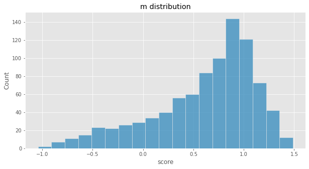

```python
plt.rcParams["figure.figsize"] = (10, 5)

seaborn.histplot(data=stats_df, x="m").set(
        title='m distribution',
        xlabel='score',
        ylabel='Count')
```

At last, our $m$ distribution is visualized. As promised, there are no significant outliers, and there is a reasonable bound in either direction.

The next step is to combine our dataframes, so that tournament results also have an $m$ score attached to them.

```python
# merge our stats df + tournaments df
full = pd.merge(upper, stats_df, on="id")


# convert date str to datetime
full['Date'] = pd.to_datetime(full['Date'].astype(str), format='%Y-%m-%d')

full.dropna()
print(full.shape)
full.head(3)
```

```
(30374, 15)
```

|  | id | Date | Rank | Series | W_L | Win | Loss | Forfeit | Absence | Winrate | Streak(Wins) | m | p | n | push_class |
| --- | --- | --- | --- | --- | --- | --- | --- | --- | --- | --- | --- | --- | --- | --- | --- |
| 0 | 1 | 1990-03-01 | J12w | LLWWLWWLLWWWWLL | 8-7 | 8.0 | 7.0 | 0.0 | 0.0 | 53.33 | Y | 0.027626 | 0.490066 | 604.0 | Moderate other |
| 1 | 1 | 1990-05-01 | J10w | LWWWWWWWLLWLWWW | 11-4 | 11.0 | 4.0 | 0.0 | 0.0 | 73.33 | Y | 0.027626 | 0.490066 | 604.0 | Moderate other |
| 2 | 1 | 1990-07-01 | J3e | WWWWLWLLWWLWWWW | 11-4 | 11.0 | 4.0 | 0.0 | 0.0 | 73.33 | Y | 0.027626 | 0.490066 | 604.0 | Moderate other |

Note that our dataframe now has the `m` and the human-defined `push_class` columns for every tournament. Let's visualize them:

```
[Text(0.5, 1.0, 'pusher classification tournament count')]
```

[figure not shown]

```python
seaborn.countplot(  x="push_class",
                    order=['Full pusher', 'Moderate pusher', 'Moderate other', 'Full other'],
                    data=stats_df ).set(
                    title='pusher classification tournament count')
```

```
[Text(0.5, 1.0, 'wins against pusher classification'),
```

[figure not shown]

```python
# doesn't look like a whole lot of difference from immediate metric comparison.
# note that the counts are very different, as shown above
seaborn.violinplot(data=full,
                   x='push_class',
                   y='Win',
                   order=['Full pusher', 'Moderate pusher', 'Moderate other', 'Full other']
                  ).set(
                    title='wins against pusher classification',
                    xlabel='wins',
                    ylabel='metric score'
                  )
```

Visualizing the wins by the classification shows us something a bit peculiar: the "moderate other" category seems to have a fairly high average win number compared to the others. However, relating to our question, nothing significant can be gleaned. Note the strange shape of the "full other" category: this is caused by the number of discrete values (tournament wins can only be 0-15, after all) in the distribution. There are nearly 25,000 members of the distribution, so the discrete peaks within the violin plot are pronounced significantly.

We stick with the plan, and process consecutive tournaments.

### Bucketed win visualization (human cutoffs)

```python
"""
This code looks processes X **consecutive** tournaments based on an origin "bucket."
These buckets are defined by wins, with the following cutoffs:
    bad/low score: wins < 6
    ok/mid score: 6 <= wins <= 10
    good/high score: wins > 11
It then returns the average run of the tournament series, for each frame passed,
and for each origin bucket.

frames is the selected tournament data of each category to be processed.
window is the amount of consecutive tournaments to look at.
    for example, window=2 only looks at a tournament and the next performance.
"""

def compute_runs(frames, window):

    sig_wins_high = 11
    sig_wins_low = 6


    l = len(frames)

    # get WIN HISTORY of three tourneys from starting point of low wins, med wins, high wins
    # [ [low_1, low_2, low_3, n]    [...]    [...]]
    scopes = [ [[0] * (window+1) for i in range(0, 3)] for j in range(0, l) ]

    # get the DIFFERENCE of wins in basho
    diff = [ [[] * l for i in range(0, 3)] for j in range(0, l) ]

    sec_in_months = 2629800


    # for each frame,
    for m in range(0, l):

        # for each id,
        for w_id, group in frames[m].groupby("id"):

            # reset index to make sure we can access consecutive rows
            group.reset_index(inplace=True)

            # for each tournament,
            for i, row in group.iterrows():

                if i < group.shape[0] - (window-1): # make sure we're not trying to grab data past the last two basho

                    # find which win bucket this basho belongs to
                    k = 0
                    if row.Win < sig_wins_low: # low w
                        k = 0
                    elif row.Win < sig_wins_high: # med w
                        k = 1
                    else: # high w
                        k = 2

                    # setting the win differential for the next row
                    diff[m][k].append(group['Win'].iat[i] - group['Win'].iat[i+1])

                    # we should only be recording CONSECUTIVE bashos. check for this by
                    # seeing how long it is between the first and third basho.
                    # they happen every two months, so the time span should be four months.
                    td = abs(group['Date'].iat[i+window-1] - group['Date'].iat[i])

                    # the time diff has to be within two months * window
                    if td.total_seconds() < 2 * sec_in_months * (window-1) + 604800:
                        for pos in range(window):
                            scopes[m][k][pos] += group['Win'].iat[i+pos]

                        scopes[m][k][window] += 1
                    else:
                        pass


    # calculating averages after summing the tournament types
    res = [ [[0] * window for i in range(0, 3)] for j in range(0, l) ]

    for m in range(0, l):
        for i in range(0, 3):
            for j in range(0, window):
                res[m][i][j] = scopes[m][i][j] / scopes[m][i][window]



    return(res, diff)
```

```python
# selecting the dataframes to go through by class
full_pushers = full.query("push_class == 'Full pusher'")
mod_pushers = full.query("push_class == 'Moderate pusher'")
full_others = full.query("push_class == 'Full other'")
mod_others = full.query("push_class == 'Moderate other'")

frames = [full_pushers, mod_pushers, mod_others, full_others]

res, diff = compute_runs(frames, 3)
```

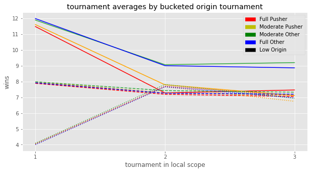

```python
# we want to see the progression between tournaments. line graph of all buckets
#         full push   mod push  mod other   full other
#           red        orange     green        blue
colors = ['#ff0000', '#ffa500', '#32a840', '#0000FF']
lines = [":",  "--", "-" ]
i = 0
j = 0
k = 0

for m in res: # for pusher class (full push, etc.)
    for t_type in m: # for tournament type (low origin, mid, etc.)
        ax = seaborn.lineplot(x=[0, 1, 2], y=t_type, color=colors[i])
        ax.set( title='tournament averages by bucketed origin tournament',
                xlabel='tournament in local scope',
                ylabel='wins')
        plt.xticks([0,1,2], ("1", "2", "3"))
        ax.lines[k].set_linestyle(lines[j])
        j+=1
        k+=1
    j = 0
    i += 1

handles = [mpatches.Patch(color='r', label='Full Pusher'), mpatches.Patch(color='y', label='Moderate Pusher'),
           mpatches.Patch(color='g', label='Moderate Other'), mpatches.Patch(color='b', label='Full Other'),
           mpatches.Patch(color='k', label='Low Origin', linestyle='--'),]
plt.legend(handles=handles)
plt.show()
```

The trajectories within tournament origins seem to be very similar... Except for the high origin. There is a noticeable difference between the moderate classes at tournament 2. Let's take a closer look.

[figure not shown]

```python
# change the scope to two consecutive tournaments
res, diff = compute_runs(frames, 2)
i = 0
for m in res: # for pusher class (full push, etc.)
    seaborn.lineplot(x=[0, 1], y=m[2], color=colors[i]).set(
                            title='tournament averages per classification with 12+ wins origin',
                            xlabel='tournament in local scope',
                            ylabel='wins')
    plt.xticks([0,1], ("1", "2"))
    i += 1
```

[figure not shown]

```
 [Text(0, 0, 'Full oshi'),
```

[figure not shown]

```python
# we recorded the differences earlier!
seaborn.violinplot(data=[diff[0][0], diff[1][0], diff[2][0], diff[3][0]]).set(
                    title='high origin next tournament win differentials',
                    xlabel='win bucket',
                    ylabel='wins difference'
                  )

plt.xticks([0, 1, 2, 3], ('Full oshi', 'Moderate oshi', 'Moderate other', 'Full other'))
```

What may be going on here is that most yokozuna are classified as a non-pusher. Since yokozuna are especially dominant wrestlers, they may be skewing these results. Let's process again without them.

```
(30374, 15)
(30374, 15)
```

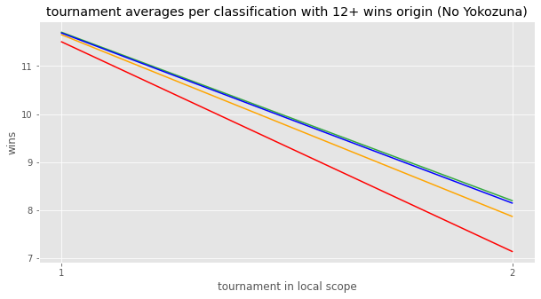

```python
#getting rid of yokozuna!
print(full.shape)
no_yokozuna = full[full.Rank.apply(lambda x: x.lower()[0] != 'y')]
print(full.shape)

# selecting the dataframes to go through by class
full_pushers = no_yokozuna.query("push_class == 'Full pusher'")
mod_pushers = no_yokozuna.query("push_class == 'Moderate pusher'")
full_others = no_yokozuna.query("push_class == 'Full other'")
mod_others = no_yokozuna.query("push_class == 'Moderate other'")
frames = [full_pushers, mod_pushers, mod_others, full_others]
res, diff = compute_runs(frames, 2)

i = 0
for m in res: # for pusher class (full push, etc.)
    seaborn.lineplot(x=[0, 1], y=m[2], color=colors[i]).set(
                            title='tournament averages per classification with 12+ wins origin (No Yokozuna)',
                            xlabel='tournament in local scope',
                            ylabel='wins')
    plt.xticks([0,1], ("1", "2"))
    i += 1
```

Although the pattern is reduced, it is still there. This result seems to be generalized!

## Pusher classification by logistic regression

The cutoffs for classification were somewhat arbitrary: let's try to classify our wrestlers automatically. Since we have two supposed classes, we can try using logistic regression to classify our data by the $m$ feature. This method requires a training dataset, which is equivalent to the `pushers` and `non_pushers` in the exploratory analysis from section 1.

```python
# we don't use the human cutoffs anymore
stats_df.drop(['push_class'], axis=1, inplace=True)
full.drop(['push_class'], axis=1, inplace=True)
```

[output not shown]

```python
def push_class_logistic(data):

    # this is with accordance to the exploratory scraping in section 1
    pusherID = [12191,11985,8,12094,12043,11855,12239,5944,11934,7240]
    nonID = [11927,1123,12451,11868,1111,12107,12412,6599,11728,878,4,1]

    data['push_class_numeric'] = np.nan

    # initializing our training data
    for i, row in data.iterrows():
        if int(row['id']) in  pusherID:
            data.loc[i,"push_class_numeric"] = 0
        elif row['id'] in  nonID:
            data.loc[i,"push_class_numeric"] = 1

    # defining the training df
    df = data.loc[data['id'].isin(pusherID) | data['id'].isin(nonID)]

    # making our training set
    train_targ = df["push_class_numeric"].values
    train_feat = [[m] for m in df["m"]]

    # fitting the model
    lr = LogisticRegression()
    lr.fit(train_feat, train_targ)
    #print(lr.predict(test_feat)

    data.drop(['push_class_numeric'], axis=1, inplace=True)

    y_km = lr.predict([[m] for m in data["m"]])
    arr1 = ['Pusher' if i == 0 else 'Non-Pusher' for i in y_km]
    return(arr1)


stats_df['push_class_LogisticRegression'] = push_class_logistic(stats_df)
stats_df.head(3)
```

```python
ax2 = seaborn.countplot(x="push_class_LogisticRegression", order=['Pusher', 'Non-Pusher'], data=stats_df)
ax2.set_title("LogisticRegression")
```

[output not shown]

```python
seaborn.histplot(data=stats_df.loc[stats_df['push_class_LogisticRegression'] == 'Pusher'], x="m", color="red").set(
        title='m distribution',
        xlabel='score',
        ylabel='Count')

seaborn.histplot(data=stats_df.loc[stats_df['push_class_LogisticRegression'] == 'Non-Pusher'], x="m", color="blue").set(
        title='m distribution (logistic regression)',
        xlabel='score',
        ylabel='Count')
```

[output not shown]

```python
# again, we merge to and properly set up dataframes for time series processing
full = pd.merge(upper, stats_df, on="id")
full['Date'] = pd.to_datetime(full['Date'].astype(str), format='%Y-%m-%d')
full.dropna()

# convert date str to datetime
pushers = full.query("push_class_LogisticRegression == 'Pusher'")
non_pushers = full.query("push_class_LogisticRegression == 'Non-Pusher'")
frames = [pushers, non_pushers]

res, diff = compute_runs(frames, 2)
```

```python
i = 0
j = 0
k = 0

for m in res: # for pusher class (full push, etc.)
    for t_type in m: # for tournament type (low origin, mid, etc.)
        ax = seaborn.lineplot(x=[0, 1], y=t_type, color=['red', 'blue'][i])
        ax.set( title='tournament averages by bucketed origin tournament (logistic regression)',
                xlabel='tournament in local scope',
                ylabel='wins')
        plt.xticks([0,1], ("1", "2"))
        ax.lines[k].set_linestyle(lines[j])
        j+=1
        k+=1
    j = 0
    i += 1

handles = [mpatches.Patch(color='r', label='Pusher'), mpatches.Patch(color='b', label='Non-Pusher')]
plt.legend(handles=handles)
plt.show()
```

[output not shown]

## Classification with k-means clustering

There is an alternative to logistic regression in this scenario. Instead of using a supervised regression algorithm, we can also attempt to use an unsupervised clustering algorithm for classification. This may fit our data better. Initially, we had full and moderate classes for each style, resulting in four total classifications. Maybe we can replicate those results.

We will attempt k-means clustering for up to four clusters.

```python
# fit k-means to the m score
def push_class_kmeans(data, k):
    kmeans = KMeans(n_clusters = k)
    arr = [[0, i] for i in data['m']]
    y_km = kmeans.fit_predict(arr)
    return(y_km)

# classify based on each k amount
stats_df['push_class_KMeans2'] = push_class_kmeans(stats_df, 2)
stats_df['push_class_KMeans3'] = push_class_kmeans(stats_df, 3)
stats_df['push_class_KMeans4'] = push_class_kmeans(stats_df, 4)
stats_df.head()
```

```python
ax2 = seaborn.countplot(x="push_class_KMeans2", order=[1, 0], data=stats_df)
ax2.set_title("KMeans (k=2)")
```

[output not shown]

```python
def make_kmeans_graph(k, axes):
    for i in range(0, k):
        seaborn.histplot(data=stats_df.loc[stats_df[f'push_class_KMeans{k}'] == i],
                         x="m",
                         color=colors[i],
                         ax=axes).set(
                        title=f'm distribution (k means k={k})',
                        xlabel='score',
                        ylabel='Count')
```

```
(0.0, 1.0, 0.0, 1.0)
```

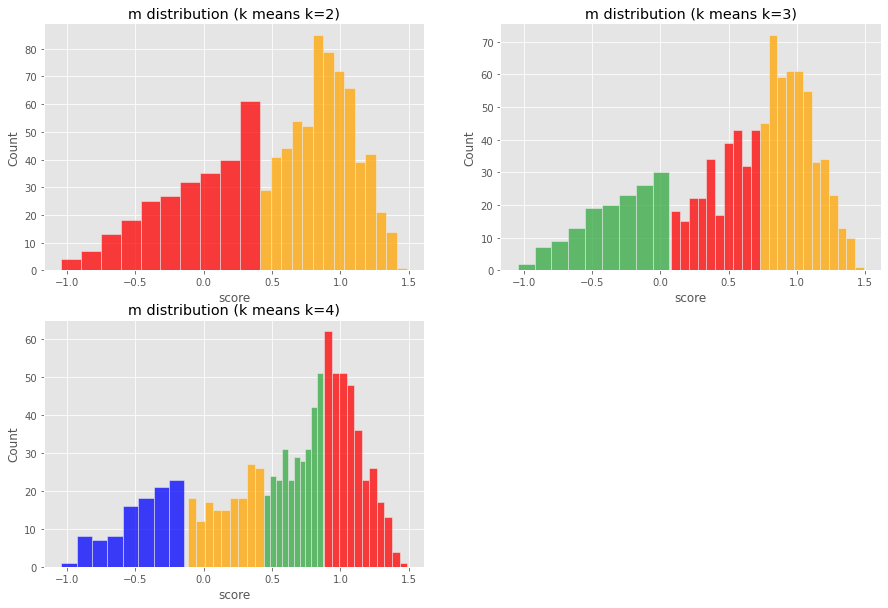

```python
plt.rcParams["figure.figsize"] = (15, 10)

f, axes = plt.subplots(2, 2)
make_kmeans_graph(2, axes[0, 0])
make_kmeans_graph(3, axes[0, 1])
make_kmeans_graph(4, axes[1, 0])
axes[1, 1].axis('off')
```

Overall, this doesn't seem to be a good algorithm for this classification task. This is because the algorithm searches for local means: in our data, the pushers do not have a pronounced cluster, while the other styles do. This results in an expansive boundary for `k=2`, as seen in the top left. Increasing cluster size does not yield meaningful results. Logistic regression would be the best option for dividing the dataset into classes based on $m$ score, but if other features were included, perhaps k-means would prove to be more meaningful.

[figure not shown]

# Section 5: Prediction

## Fitting a prediction model and Null Hypothesis

Another way of determining whether or not pushers are streaky is to make a prediction model with multiple variables and look at the relationship between all of the variables and see if it is any different from pushers and non-pushers. However, due note that it will be very hard to accurately predict expected wins for the sumo tournament, since there are lots of external factors that could affect the player's wins in a tournament that we don't have the data on (such as player injury, condition on that day, etc). Hopefully, we see a p-value < 0.05, so that we can show that all of the variables are somewhat correlated.

## Prepping the dataframe

In order to do our best effort on accurately predicting a player's expected wins based on their fields, we will include as much variables that we think that might affect the player's expected wins

- m-scores
- Division of the player
- Rank in the division
- Previous wins (in the tournament before)

and in order to use all these data in a model, we will need to do some prepping for the dataframe

```python
# get rid of the classifications
#full.drop(['push_class_KMeans2', 'push_class_KMeans3', 'push_class_KMeans4'], axis=1, inplace=True)

# we're going to want to have the wins of the previous basho as a feature in our predictive model
full['prev_wins'] = np.nan

# getting previous tournament wins (less than 2 months apart)
for i, row in full.iterrows():
    if i < full.shape[0] - 1:
        if(full['id'].iat[i+1]  == full['id'].iat[i]):
            td = abs(full['Date'].iat[i+1] - full['Date'].iat[i])
            if td.total_seconds() < 5616000: # diff is less than 65 days (2 months 5 days)
                full['prev_wins'].iat[i+1] = full['Win'].iat[i]

full.head(2)
```

[output not shown]

```python
# here we will prep the dataframe by separating the division and the rank from the rank column
pd.options.mode.chained_assignment = None

ranks = pd.DataFrame(full.Rank.apply(lambda x: rank_helper.full_rank(x)))
rank_list = ranks['Rank'].tolist()
full[['div','rank']] = pd.DataFrame(rank_list, index = ranks.index)

# rename column name of the streak, so that we can use it in the formula without error (parenthesis will confuse it)
full.rename({'Streak(Wins)': 'Streak'}, axis = 1, inplace = True)

full.head(2)
```

|  | id | Date | Rank | Series | W_L | Win | Loss | Forfeit | Absence | Winrate | Streak | m | p | n | push_class_LogisticRegression | prev_wins | div | ranked | rank |
| --- | --- | --- | --- | --- | --- | --- | --- | --- | --- | --- | --- | --- | --- | --- | --- | --- | --- | --- | --- |
| 0 | 1 | 1990-03-01 | J12w | LLWWLWWLLWWWWLL | 8-7 | 8.0 | 7.0 | 0.0 | 0.0 | 53.33 | Y | 0.027626 | 0.490066 | 604.0 | Pusher | NaN | Juryo | 12 | 12 |
| 1 | 1 | 1990-05-01 | J10w | LWWWWWWWLLWLWWW | 11-4 | 11.0 | 4.0 | 0.0 | 0.0 | 73.33 | Y | 0.027626 | 0.490066 | 604.0 | Pusher | 8.0 | Juryo | 10 | 10 |

## Fitting a prediction model for the pushers

Since we are dealing with pushers and non-pushers, it will be appropriate to create two prediction model, so that we can compare the difference between the two.

Like we have talked above, the major variables that we think that will affect the expected wins are

- m-score
- division
- rank in the division
- wins in previous tournament

So the equation of the regression will be:

$\text{Expected Wins} = m(x) + div(x) + rank(x) + prev\_wins(x)$

```python
# only include pushers
pushers = full.loc[full['push_class_LogisticRegression'] == 'Pusher']
est2 = smf.ols(formula='Win ~ m + div + rank + prev_wins', data = pushers).fit()
est2.summary()

# NOTE: Juryo == dummy variable!!!
```

OLS Regression Results

| Dep. Variable: | Win | R-squared: | 0.045 |
| --- | --- | --- | --- |
| Model: | OLS | Adj. R-squared: | 0.043 |
| Method: | Least Squares | F-statistic: | 23.66 |
| Date: | Mon, 17 May 2021 | Prob (F-statistic): | 8.81e-36 |
| Time: | 00:54:03 | Log-Likelihood: | -9136.7 |
| No. Observations: | 4005 | AIC: | 1.829e+04 |
| Df Residuals: | 3996 | BIC: | 1.835e+04 |
| Df Model: | 8 |  |  |
| Covariance Type: | nonrobust |  |  |

|  | coef | std err | t | P>\|t\| | [0.025 | 0.975] |
| --- | --- | --- | --- | --- | --- | --- |
| Intercept | 7.5946 | 0.171 | 44.414 | 0.000 | 7.259 | 7.930 |
| div[T.Komusubi] | -0.5045 | 0.208 | -2.424 | 0.015 | -0.913 | -0.096 |
| div[T.Maegashira] | -0.5657 | 0.083 | -6.822 | 0.000 | -0.728 | -0.403 |
| div[T.Ozeki] | 0.7244 | 0.217 | 3.339 | 0.001 | 0.299 | 1.150 |
| div[T.Sekiwake] | 0.6032 | 0.201 | 3.003 | 0.003 | 0.209 | 0.997 |
| div[T.Yokozuna] | 3.9482 | 0.425 | 9.288 | 0.000 | 3.115 | 4.782 |
| m | 0.1673 | 0.138 | 1.208 | 0.227 | -0.104 | 0.439 |
| rank | 0.0230 | 0.009 | 2.462 | 0.014 | 0.005 | 0.041 |
| prev_wins | -0.0335 | 0.018 | -1.894 | 0.058 | -0.068 | 0.001 |

| Omnibus: | 157.040 | Durbin-Watson: | 2.023 |
| --- | --- | --- | --- |
| Prob(Omnibus): | 0.000 | Jarque-Bera (JB): | 185.270 |
| Skew: | -0.455 | Prob(JB): | 5.88e-41 |
| Kurtosis: | 3.533 | Cond. No. | 122. |

Notes:  
[1] Standard Errors assume that the covariance matrix of the errors is correctly specified.

## Uh oh

```python
est2 = smf.ols(formula='Win ~ div + rank + prev_wins', data = pushers).fit()
est2.summary()
```

OLS Regression Results

| Dep. Variable: | Win | R-squared: | 0.045 |
| --- | --- | --- | --- |
| Model: | OLS | Adj. R-squared: | 0.043 |
| Method: | Least Squares | F-statistic: | 26.83 |
| Date: | Mon, 17 May 2021 | Prob (F-statistic): | 3.31e-36 |
| Time: | 00:54:03 | Log-Likelihood: | -9137.4 |
| No. Observations: | 4005 | AIC: | 1.829e+04 |
| Df Residuals: | 3997 | BIC: | 1.834e+04 |
| Df Model: | 7 |  |  |
| Covariance Type: | nonrobust |  |  |

|  | coef | std err | t | P>\|t\| | [0.025 | 0.975] |
| --- | --- | --- | --- | --- | --- | --- |
| Intercept | 7.5262 | 0.161 | 46.646 | 0.000 | 7.210 | 7.843 |
| div[T.Komusubi] | -0.4871 | 0.208 | -2.346 | 0.019 | -0.894 | -0.080 |
| div[T.Maegashira] | -0.5684 | 0.083 | -6.857 | 0.000 | -0.731 | -0.406 |
| div[T.Ozeki] | 0.7228 | 0.217 | 3.331 | 0.001 | 0.297 | 1.148 |
| div[T.Sekiwake] | 0.6220 | 0.200 | 3.106 | 0.002 | 0.229 | 1.015 |
| div[T.Yokozuna] | 4.0169 | 0.421 | 9.535 | 0.000 | 3.191 | 4.843 |
| rank | 0.0238 | 0.009 | 2.555 | 0.011 | 0.006 | 0.042 |
| prev_wins | -0.0332 | 0.018 | -1.877 | 0.061 | -0.068 | 0.001 |

| Omnibus: | 156.691 | Durbin-Watson: | 2.022 |
| --- | --- | --- | --- |
| Prob(Omnibus): | 0.000 | Jarque-Bera (JB): | 184.942 |
| Skew: | -0.454 | Prob(JB): | 6.92e-41 |
| Kurtosis: | 3.534 | Cond. No. | 120. |

Notes:  
[1] Standard Errors assume that the covariance matrix of the errors is correctly specified.

```python
est2.params
```

```
Intercept            7.526177
div[T.Komusubi]     -0.487095
div[T.Maegashira]   -0.568435
div[T.Ozeki]         0.722785
div[T.Sekiwake]      0.622010
div[T.Yokozuna]      4.016853
rank                 0.023839
prev_wins           -0.033184
dtype: float64
```

## Fitting a prediction model for non-pushers

```python
# only include non-pushers
non_pushers = full.loc[full['push_class_LogisticRegression'] == 'Non-Pusher']
est3 = smf.ols(formula='Win ~ div + rank + prev_wins', data = non_pushers).fit()
est3.summary()
```

OLS Regression Results

| Dep. Variable: | Win | R-squared: | 0.100 |
| --- | --- | --- | --- |
| Model: | OLS | Adj. R-squared: | 0.099 |
| Method: | Least Squares | F-statistic: | 323.5 |
| Date: | Mon, 17 May 2021 | Prob (F-statistic): | 0.00 |
| Time: | 01:01:45 | Log-Likelihood: | -47274. |
| No. Observations: | 20468 | AIC: | 9.456e+04 |
| Df Residuals: | 20460 | BIC: | 9.463e+04 |
| Df Model: | 7 |  |  |
| Covariance Type: | nonrobust |  |  |

|  | coef | std err | t | P>\|t\| | [0.025 | 0.975] |
| --- | --- | --- | --- | --- | --- | --- |
| Intercept | 6.8784 | 0.071 | 96.500 | 0.000 | 6.739 | 7.018 |
| div[T.Komusubi] | -0.6450 | 0.099 | -6.509 | 0.000 | -0.839 | -0.451 |
| div[T.Maegashira] | -0.5628 | 0.038 | -14.980 | 0.000 | -0.636 | -0.489 |
| div[T.Ozeki] | 1.6917 | 0.082 | 20.719 | 0.000 | 1.532 | 1.852 |
| div[T.Sekiwake] | 0.6506 | 0.099 | 6.551 | 0.000 | 0.456 | 0.845 |
| div[T.Yokozuna] | 3.1757 | 0.102 | 31.190 | 0.000 | 2.976 | 3.375 |
| rank | 0.0349 | 0.004 | 8.236 | 0.000 | 0.027 | 0.043 |
| prev_wins | 0.0363 | 0.008 | 4.740 | 0.000 | 0.021 | 0.051 |

| Omnibus: | 1321.961 | Durbin-Watson: | 2.034 |
| --- | --- | --- | --- |
| Prob(Omnibus): | 0.000 | Jarque-Bera (JB): | 1909.670 |
| Skew: | -0.556 | Prob(JB): | 0.00 |
| Kurtosis: | 4.000 | Cond. No. | 74.9 |

Notes:  
[1] Standard Errors assume that the covariance matrix of the errors is correctly specified.

```python
est3.params
```

```
Intercept            6.878438
div[T.Komusubi]     -0.645013
div[T.Maegashira]   -0.562842
div[T.Ozeki]         1.691678
div[T.Sekiwake]      0.650589
div[T.Yokozuna]      3.175748
rank                 0.034922
prev_wins            0.036290
dtype: float64
```

# What can we see from the Model?

# Is there any difference between the two model? What does it tell us?

# How does our model do in regards of prediction?

$residual = actual - predicted$

```python
# helper function to predict the values for the pushers
def predict_p(m,div,ranked,prev_wins):
    d = [['',0,0]]
    f1 = pd.DataFrame(d, columns = ['div','rank','prev_wins'])

    f1['div'].iat[0] = div
    f1['rank'].iat[0] = ranked
    f1['prev_wins'].iat[0] = prev_wins

    p = est2.predict(f1.loc[:,['div','rank','prev_wins']])
    return p.iloc[0]

# helper function to predict the values for the non-pushers
def predict_o(m,div,ranked,prev_wins):
    d = [['',0,0]]
    f1 = pd.DataFrame(d, columns = ['div','rank','prev_wins'])

    f1['div'].iat[0] = div
    f1['rank'].iat[0] = ranked
    f1['prev_wins'].iat[0] = prev_wins

    p = est3.predict(f1.loc[:,['div','rank','prev_wins']])
    return p.iloc[0]
```

```python
# we can use the prediction to calculate the intercept for both groups
print(predict_p(0,"Juryo",0,0))
print(predict_o(0,"Juryo",0,0))

# calculating residuals
pushers['predict'] = est2.predict(pushers.loc[:,['div','rank','prev_wins']])
pushers['residuals'] =  pushers['Win'] - pushers['predict']

non_pushers['predict'] = est3.predict(non_pushers.loc[:,['div','rank','prev_wins']])
non_pushers['residuals'] =  non_pushers['Win'] - non_pushers['predict']
```

```
7.5261774197569515
6.87843771554299
```

```
[Text(0.5, 1.0, 'Previous tournament wins vs Residuals for pushers'),
```

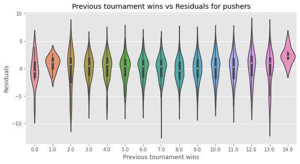

```python
plt.rcParams["figure.figsize"] = (10, 5)

seaborn.violinplot(x="prev_wins",y='residuals', data = pushers).set(
                    title='Previous tournament wins vs Residuals for pushers',
                    xlabel='Previous tournament wins',
                    ylabel='Residuals')
```

```
[Text(0.5, 1.0, 'Previous tournament wins vs Residuals for non'),
```

[figure not shown]

```python
seaborn.violinplot(x="prev_wins",y='residuals', data = non_pushers).set(
                    title='Previous tournament wins vs residuals for non-pusher',
                    xlabel='Previous tournament wins',
                    ylabel='Residuals')
```

# What can we see?

We can see that residuals are all over ther place when we plot previous tournament wins vs residuals for both of the model, which suggests that our prediction model is not as accurate as we wanted it to be when it comes to predicting expected wins based on previous tournament wins.

[figure not shown]

# Conclusion

From the tournament series, it is evident that **pushers tend to lose more often in their tournament after performing well** as compared to non-pushers. We observed this trend even in the yokozuna-less data. The cause for this result may have various potential sources, which cannot be observed within the present data:

- The oshi style may be more inconsistent in win volume because of mechanical reasons.
- Oshi sumo may be more susceptible to injuries, which hinders long term performance.

## Future directions

- Explore to see if the lower division data also holds this result.
- Comparing multiple fighting styles explicitly -- maybe even finding an unexpected one!
- Look at bouts across time periods to see if this trend holds true